# Project1

## Ryder Davis rkd473

### The datasets I have chosen both are about professional golf statistics. I played golf for my high school, so I have a deeper than average understanding of the game. Seeing a professional play just amazes me as how good they are. I don’t think many people realize how precise and consistent you have to be to even play in a pro tournament. I expect that the majority of the statistics will be very close among all the players because winning in golf at that level comes down to whether or not you had a good day/week.

### The initial dataset was about 10 million rows long with a couple hundred tournament results, so I picked out the earliest tournament and the latest tournament in the dataset. After tidying, there was over 1,000 columns with various statistics. For each of the tournaments I had chosen, I selected 4 unique statistics that I found to be important. Also, I selected the average score in both datasets. These variables I chose were things like putts per round, driving distance and accuracy, average approach distance, money earned, and a few more fundamental statistics.

```r
library(tidyverse)
library(cluster)

golf <- read.csv("/stor/work/SDS348_Fall2019/2019_data.csv")
golfx <- golf %>% select(-Statistic)
earlygolf <- golfx %>% filter(Date == "2019-01-27")
endgolf <- golfx %>% filter(Date == "2019-08-25")

earlygolf1 <- earlygolf %>% pivot_wider(names_from = "Variable",
    values_from = "Value")
earlygolf2 <- earlygolf1 %>% select(Player.Name, Date, "Average Approach Shot Distance - (AVG)",
    "Average Distance of Putts made - (AVG DIST.)", "Club Head Speed - (AVG.)",
    "One-Putt Percentage - (%)", "Scoring Average (Actual) - (AVG)") %>%
    na.omit

endgolf1 <- endgolf %>% pivot_wider(names_from = "Variable",
    values_from = "Value")
endgolf2 <- endgolf1 %>% select(Player.Name, Date, "Driving Accuracy Percentage - (%)",
    "Driving Distance - (AVG.)", "Official Money - (MONEY)",
    "Scoring Average (Actual) - (AVG)", "Putts Per Round - (AVG)") %>%
    na.omit

innergolf <- endgolf2 %>% inner_join(earlygolf2, by = "Player.Name",
    suffix = c(".late", ".early"))
221 - 180
```

```
## [1] 41
```

```r
187 - 180
```

```
## [1] 7
```

```r
cleandata <- innergolf %>% rename(Name = "Player.Name", DriveAcc = "Driving Accuracy Percentage - (%)",
    DriveDist = "Driving Distance - (AVG.)", Money = "Official Money - (MONEY)",
    Score2 = "Scoring Average (Actual) - (AVG).late", Putts = "Putts Per Round - (AVG)",
    ApproachDist = "Average Approach Shot Distance - (AVG)",
    PuttsMadeDist = "Average Distance of Putts made - (AVG DIST.)",
    ClubSpeed = "Club Head Speed - (AVG.)", OnePuttPerc = "One-Putt Percentage - (%)",
    Score1 = "Scoring Average (Actual) - (AVG).early") %>% select(-Date.early,
    -Date.late)

cleandata2 <- cleandata
cleandata2$Score2 <- as.numeric(as.character(cleandata2$Score2))
cleandata2$Score1 <- as.numeric(as.character(cleandata2$Score1))

cleandata3 <- cleandata2 %>% separate(col = PuttsMadeDist, into = c("Feet",
    "Inches"), sep = "' ", convert = T) %>% separate(col = Inches,
    into = c("In", NA), convert = T) %>% mutate(PuttsMadeDist = Feet +
    (In/12)) %>% select(-Feet, -In)

cleandata4 <- cleandata3 %>% separate(col = Money, into = c(NA,
    "a", "b", "c")) %>% unite(a, b, c, col = "Money", sep = "",
    remove = TRUE, na.rm = TRUE)
cleandata4$DriveAcc <- as.numeric(as.character(cleandata4$DriveAcc))
cleandata4$DriveDist <- as.numeric(as.character(cleandata4$DriveDist))
cleandata4$Putts <- as.numeric(as.character(cleandata4$Putts))
cleandata4$ApproachDist <- as.numeric(as.character(cleandata4$ApproachDist))
cleandata4$OnePuttPerc <- as.numeric(as.character(cleandata4$OnePuttPerc))
cleandata4$ClubSpeed <- as.numeric(as.character(cleandata4$ClubSpeed))
cleandata4$Money <- as.numeric(cleandata4$Money)
cleandata4$Name <- as.character(cleandata4$Name)

finaldata <- cleandata4
```

### Here I cleaned up my data. I manipulated the dataset to make all of the variables numeric. This consisted of changing the feet and inches of average putt distance made into a number based in feet only. Also, I needed to remove the dollar sign and commas from the money earned. Finally, most things were defined as factors when I called the dataset, so I switched those to numeric.

```r
finaldata %>% mutate(ScoreDiff = Score2 - Score1, Score2n = -1 *
    Score2, Score2_ntile = ntile(Score2n, 100)) %>% select(-Score2n) %>%
    select(Name, ScoreDiff, Score2, Score2_ntile) %>% head()
```

```
## # A tibble: 6 x 4
##   Name           ScoreDiff Score2 Score2_ntile
##   <chr>              <dbl>  <dbl>        <int>
## 1 Cameron Champ       2.05   70.7           29
## 2 Rory McIlroy       -1.71   69.0           99
## 3 Luke List           1.91   71.0           18
## 4 Dustin Johnson     -1.11   69.9           84
## 5 Wyndham Clark       0.06   69.8           87
## 6 Bubba Watson       -1.73   70.6           35
```

```r
div <- (max(finaldata$ClubSpeed) - min(finaldata$ClubSpeed))/3  #3 sections of club head speed

# create a categorical varibale
finaldata <- finaldata %>% mutate(ClubSpeedCat = case_when(ClubSpeed >
    (max(finaldata$ClubSpeed) - div) ~ "High", (min(finaldata$ClubSpeed) +
    div) <= ClubSpeed & ClubSpeed <= (max(finaldata$ClubSpeed) -
    div) ~ "Med", ClubSpeed < (min(finaldata$ClubSpeed) + div) ~
    "Slower")) %>% mutate(ScoreDiff = Score2 - Score1)

finaldata %>% group_by(ClubSpeedCat) %>% summarize_if(is.numeric,
    mean) %>% arrange(desc(DriveAcc))
```

```
## # A tibble: 3 x 12
##   ClubSpeedCat DriveAcc DriveDist  Money Score2 Putts ApproachDist
##   <chr>           <dbl>     <dbl>  <dbl>  <dbl> <dbl>        <dbl>
## 1 Slower           65.5      288. 1.27e6   70.5  28.9         162.
## 2 Med              60.6      298. 1.73e6   70.4  29.0         165.
## 3 High             56.8      308. 3.07e6   70.2  29.0         163.
## # … with 5 more variables: ClubSpeed <dbl>, OnePuttPerc <dbl>,
## #   Score1 <dbl>, PuttsMadeDist <dbl>, ScoreDiff <dbl>
```

```r
finaldata %>% group_by(ClubSpeedCat) %>% summarize_if(is.numeric,
    median)
```

```
## # A tibble: 3 x 12
##   ClubSpeedCat DriveAcc DriveDist  Money Score2 Putts ApproachDist
##   <chr>           <dbl>     <dbl>  <dbl>  <dbl> <dbl>        <dbl>
## 1 High             56.4      309  1.70e6   70.4  29.0         163.
## 2 Med              60.6      299. 1.07e6   70.3  28.9         164.
## 3 Slower           66.4      289. 9.41e5   70.4  28.9         162.
## # … with 5 more variables: ClubSpeed <dbl>, OnePuttPerc <dbl>,
## #   Score1 <dbl>, PuttsMadeDist <dbl>, ScoreDiff <dbl>
```

```r
row1 <- finaldata %>% summarise(mean = mean(Putts), sd = sd(Putts),
    var = var(Putts), quantile = IQR(Putts), min = min(Putts),
    med = median(Putts), max = max(Putts), ndist = n_distinct(Putts)) %>%
    round(2)

row2 <- finaldata %>% summarise(mean = mean(ApproachDist), sd = sd(ApproachDist),
    var = var(ApproachDist), quantile = IQR(ApproachDist), min = min(ApproachDist),
    med = median(ApproachDist), max = max(ApproachDist), ndist = n_distinct(ApproachDist)) %>%
    round(2)

row3 <- finaldata %>% summarise(mean = mean(Money), sd = sd(Money),
    var = var(Money), quantile = IQR(Money), min = min(Money),
    med = median(Money), max = max(Money), ndist = n_distinct(Money)) %>%
    round(2)

row4 <- finaldata %>% summarise(mean = mean(DriveAcc), sd = sd(DriveAcc),
    var = var(DriveAcc), quantile = IQR(DriveAcc), min = min(DriveAcc),
    med = median(DriveAcc), max = max(DriveAcc), ndist = n_distinct(DriveAcc)) %>%
    round(2)

row5 <- finaldata %>% summarise(mean = mean(DriveDist), sd = sd(DriveDist),
    var = var(DriveDist), quantile = IQR(DriveDist), min = min(DriveDist),
    med = median(DriveDist), max = max(DriveDist), ndist = n_distinct(DriveDist)) %>%
    round(2)

StatTable <- bind_rows(row1, row2, row3, row4, row5)

GolfStat <- c("Putts", "ApproachDist", "Money", "DriveAcc", "DriveDist")

StatTable <- cbind(GolfStat, StatTable)

StatTable
```

```
##       GolfStat       mean         sd          var   quantile       min
## 1        Putts      28.97       0.46 2.100000e-01       0.62     27.71
## 2 ApproachDist     163.57       4.55 2.073000e+01       5.38    154.60
## 3        Money 1610720.69 1504029.51 2.262105e+12 1516732.50 102127.00
## 4     DriveAcc      62.57       5.12 2.623000e+01       7.12     48.47
## 5    DriveDist     294.56       8.48 7.189000e+01      11.70    271.30
##          med        max ndist
## 1      28.92      30.21   107
## 2     163.10     176.80   108
## 3 1061096.00 9684006.00   180
## 4      62.44      75.72   173
## 5     293.95     317.90   136
```

```r
# Grouped stats
finaldata %>% group_by(ClubSpeedCat) %>% summarise(mean_putts = mean(Putts),
    sd_putts = sd(Putts), var_putts = var(Putts), quantileputts = IQR(Putts),
    min_putts = min(Putts), med_putts = median(Putts), max_putts = max(Putts),
    ndist_putts = n_distinct(Putts))
```

```
## # A tibble: 3 x 9
##   ClubSpeedCat mean_putts sd_putts var_putts quantileputts min_putts
##   <chr>             <dbl>    <dbl>     <dbl>         <dbl>     <dbl>
## 1 High               29.0    0.501     0.251         0.44       28.1
## 2 Med                29.0    0.470     0.221         0.590      27.8
## 3 Slower             28.9    0.445     0.198         0.635      27.7
## # … with 3 more variables: med_putts <dbl>, max_putts <dbl>,
## #   ndist_putts <int>
```

```r
# Correlation Matrix
NumCor <- finaldata %>% select_if(is.numeric) %>% cor

NumCor
```

```
##                   DriveAcc   DriveDist         Money      Score2
## DriveAcc       1.000000000 -0.58056248  0.0318885993 -0.22687198
## DriveDist     -0.580562481  1.00000000  0.3369622652 -0.24190194
## Money          0.031888599  0.33696227  1.0000000000 -0.62015310
## Score2        -0.226871978 -0.24190194 -0.6201530984  1.00000000
## Putts          0.136531649  0.11832569 -0.2667537141  0.36969253
## ApproachDist   0.004887919  0.16169236  0.3528722556 -0.29339299
## ClubSpeed     -0.618739947  0.84311146  0.2822848408 -0.13589082
## OnePuttPerc   -0.126074827 -0.07451994  0.0574122437 -0.18119858
## Score1        -0.095826285 -0.11890558 -0.3595689813  0.58942804
## PuttsMadeDist  0.035262057 -0.17881466  0.0015331615 -0.09867441
## ScoreDiff     -0.044469295 -0.02670533 -0.0007094655 -0.01076541
##                     Putts ApproachDist   ClubSpeed OnePuttPerc      Score1
## DriveAcc       0.13653165  0.004887919 -0.61873995 -0.12607483 -0.09582629
## DriveDist      0.11832569  0.161692360  0.84311146 -0.07451994 -0.11890558
## Money         -0.26675371  0.352872256  0.28228484  0.05741224 -0.35956898
## Score2         0.36969253 -0.293392988 -0.13589082 -0.18119858  0.58942804
## Putts          1.00000000 -0.069766630  0.11582971 -0.60681063  0.30427494
## ApproachDist  -0.06976663  1.000000000  0.25081050 -0.03811339 -0.13568412
## ClubSpeed      0.11582971  0.250810497  1.00000000 -0.08423302 -0.11673490
## OnePuttPerc   -0.60681063 -0.038113393 -0.08423302  1.00000000 -0.34504130
## Score1         0.30427494 -0.135684120 -0.11673490 -0.34504130  1.00000000
## PuttsMadeDist -0.29267841 -0.087289901 -0.12959629  0.50397742 -0.34391163
## ScoreDiff     -0.11088823 -0.042950455  0.04681321  0.29684770 -0.81411951
##               PuttsMadeDist     ScoreDiff
## DriveAcc        0.035262057 -0.0444692954
## DriveDist      -0.178814658 -0.0267053333
## Money           0.001533161 -0.0007094655
## Score2         -0.098674408 -0.0107654094
## Putts          -0.292678409 -0.1108882320
## ApproachDist   -0.087289901 -0.0429504554
## ClubSpeed      -0.129596290  0.0468132133
## OnePuttPerc     0.503977424  0.2968477036
## Score1         -0.343911632 -0.8141195111
## PuttsMadeDist   1.000000000  0.3547713839
## ScoreDiff       0.354771384  1.0000000000
```

### Next is my data exploration. I created a categorical variable based upon the club head speed, and I grouped them into high, medium, or slower speeds. After grouping by these categories and summarizing by mean, I found some things that confirmed my assumptions about swing speed and how it typically relates to other components of the game. First, the slower the swing, the better drive accuracy, which makes sense. Also, slower swing speeds average less money than the others, which I found interesting but believable. Most people who swing slower are older, so I expected them to have more precision than power. Looking at the stat table I created, the IQR really piqued my interest. For example, the IQR of putts per round 0.62. That is insane. Being able to decrease your putts per round by only 1 putt would jump you so far in front of the crowd. This is why I think so highly of professional golfers. The difference in being the best player in the world and the 100th best are such small differences. Looking at the IQR of drive distance, it is only 11.7 yards. That is such a small distance when thinking about driving the ball 300 yards. Looking at my correlation matrix, there was not anything unexpected. Things like swing speed and drive distance correlated, or score and numer of putts. Unfortunately, I did not see any “out of the box” correlations, like drive accuracy and putt percentage. Most of the high correlations were within a component of the game. For example, the short game statistics usually correlated somewhat with one another.

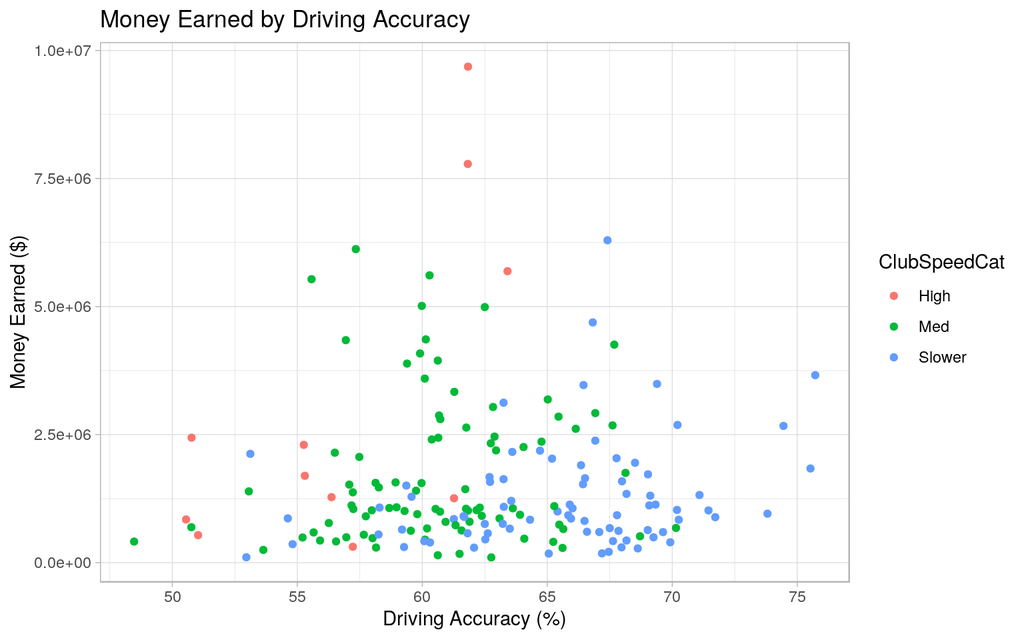

```r
library(ggplot2)
finaldata %>% ggplot(aes(DriveAcc, Money, color = ClubSpeedCat)) +
    geom_point() + xlab("Driving Accuracy (%)") + ylab("Money Earned ($)") +
    ggtitle("Money Earned by Driving Accuracy") + theme_light() +
    scale_x_continuous(breaks = seq(50, 100, 5))
```

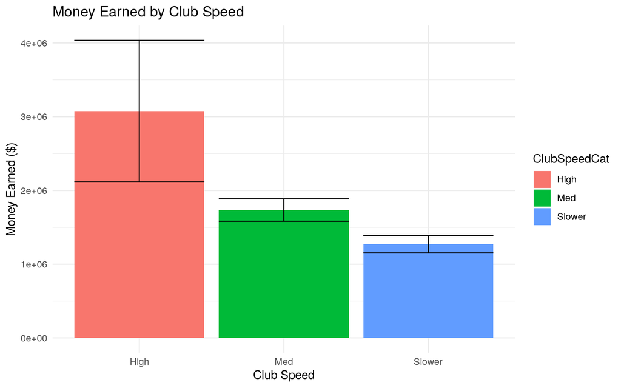

```r
finaldata %>% ggplot(aes(ClubSpeedCat, Money)) + geom_bar(stat = "summary",
    aes(fill = ClubSpeedCat)) + theme_minimal() + xlab("Club Speed") +
    ylab("Money Earned ($)") + geom_errorbar(stat = "summary") +
    ggtitle("Money Earned by Club Speed")
```

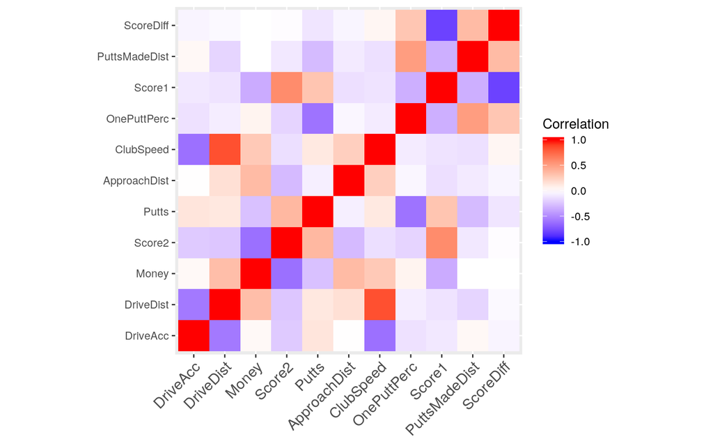

```r
library(reshape2)
mNumCor <- melt(NumCor)

mNumCor %>% ggplot(aes(Var1, Var2, fill = value)) + geom_tile() +
    scale_fill_gradient2(low = "blue", high = "red", mid = "white",
        midpoint = 0, limit = c(-1, 1), name = "Correlation") +
    theme(axis.text.x = element_text(angle = 45, vjust = 1, size = 12,
        hjust = 1), axis.title.x = element_blank(), axis.title.y = element_blank()) +
    coord_fixed()
```

### Looking at the first plot dealing with driving accuracy and money earned, there were a few things I could notice a little easier. The majority of the golfers with slower swing speeds had a higher driving accuracy. Also, the big winners in terms of money were high swing speed, most likely the younger athletes like Rory McIlroy, who have the precision of the veterans and the power of the youth. Most of the medium to high money winners had a medium swing speed, which I would presume these golfers to have a nice balance between skill and power, which is why they would win decent money. Overall, this graph is nice to look at and try to predict the ages and playstyles of the golfers. The bar graph shows an interesting significant difference in money earned. The golfers who swing harder made significantly more money than those who swing medium speeds, and the same for medium compared to slower. This is kind of funny because the average golfer gets tremondously worse if they swing harder. Another piece of evidence on how good these players actually are.

### Next is the correlation heat map, which should help to visualize what I was saying earlier. Most of the correlated variables are intuitive and fall into a similar category/ component of the game.

```r
golfpc <- finaldata %>% select(-Name, -ClubSpeedCat, -ScoreDiff) %>%
    mutate_at(c(4, 5, 6, 9), function(x) x * -1) %>% mutate_all(scale)
cov(golfpc) %>% round(2)
```

```
##               DriveAcc DriveDist Money Score2 Putts ApproachDist ClubSpeed
## DriveAcc          1.00     -0.58  0.03   0.23 -0.14         0.00     -0.62
## DriveDist        -0.58      1.00  0.34   0.24 -0.12        -0.16      0.84
## Money             0.03      0.34  1.00   0.62  0.27        -0.35      0.28
## Score2            0.23      0.24  0.62   1.00  0.37        -0.29      0.14
## Putts            -0.14     -0.12  0.27   0.37  1.00        -0.07     -0.12
## ApproachDist      0.00     -0.16 -0.35  -0.29 -0.07         1.00     -0.25
## ClubSpeed        -0.62      0.84  0.28   0.14 -0.12        -0.25      1.00
## OnePuttPerc      -0.13     -0.07  0.06   0.18  0.61         0.04     -0.08
## Score1            0.10      0.12  0.36   0.59  0.30        -0.14      0.12
## PuttsMadeDist     0.04     -0.18  0.00   0.10  0.29         0.09     -0.13
##               OnePuttPerc Score1 PuttsMadeDist
## DriveAcc            -0.13   0.10          0.04
## DriveDist           -0.07   0.12         -0.18
## Money                0.06   0.36          0.00
## Score2               0.18   0.59          0.10
## Putts                0.61   0.30          0.29
## ApproachDist         0.04  -0.14          0.09
## ClubSpeed           -0.08   0.12         -0.13
## OnePuttPerc          1.00   0.35          0.50
## Score1               0.35   1.00          0.34
## PuttsMadeDist        0.50   0.34          1.00
```

```r
golf_pca <- princomp(golfpc)
summary(golf_pca, loadings = T)
```

```
## Importance of components:
##                           Comp.1    Comp.2    Comp.3     Comp.4     Comp.5
## Standard deviation     1.6872881 1.5744525 1.2668171 0.92666158 0.85495537
## Proportion of Variance 0.2862846 0.2492749 0.1613791 0.08634989 0.07350322
## Cumulative Proportion  0.2862846 0.5355595 0.6969386 0.78328850 0.85679172
##                            Comp.6     Comp.7     Comp.8     Comp.9
## Standard deviation     0.69997588 0.58985303 0.55034534 0.40709283
## Proportion of Variance 0.04927035 0.03498703 0.03045721 0.01666504
## Cumulative Proportion  0.90606206 0.94104910 0.97150630 0.98817134
##                           Comp.10
## Standard deviation     0.34297146
## Proportion of Variance 0.01182866
## Cumulative Proportion  1.00000000
##
## Loadings:
##               Comp.1 Comp.2 Comp.3 Comp.4 Comp.5 Comp.6 Comp.7 Comp.8
## DriveAcc       0.168  0.356 -0.535 -0.182               -0.380
## DriveDist     -0.340 -0.454  0.110 -0.195               -0.281  0.167
## Money         -0.427        -0.320         0.220  0.619        -0.519
## Score2        -0.440  0.160 -0.339 -0.128  0.223        -0.170  0.569
## Putts         -0.290  0.334  0.241  0.484  0.357         0.329  0.265
## ApproachDist   0.251         0.321 -0.567  0.682  0.154
## ClubSpeed     -0.326 -0.464  0.150 -0.122 -0.127
## OnePuttPerc   -0.237  0.351  0.434  0.152        -0.130 -0.690 -0.313
## Score1        -0.390  0.235        -0.453 -0.105 -0.547  0.359 -0.360
## PuttsMadeDist -0.135  0.357  0.328 -0.329 -0.523  0.515  0.154  0.268
##               Comp.9 Comp.10
## DriveAcc      -0.543  0.279
## DriveDist      0.129  0.705
## Money
## Score2         0.317 -0.374
## Putts         -0.365  0.268
## ApproachDist
## ClubSpeed     -0.665 -0.417
## OnePuttPerc          -0.117
## Score1                0.114
## PuttsMadeDist
```

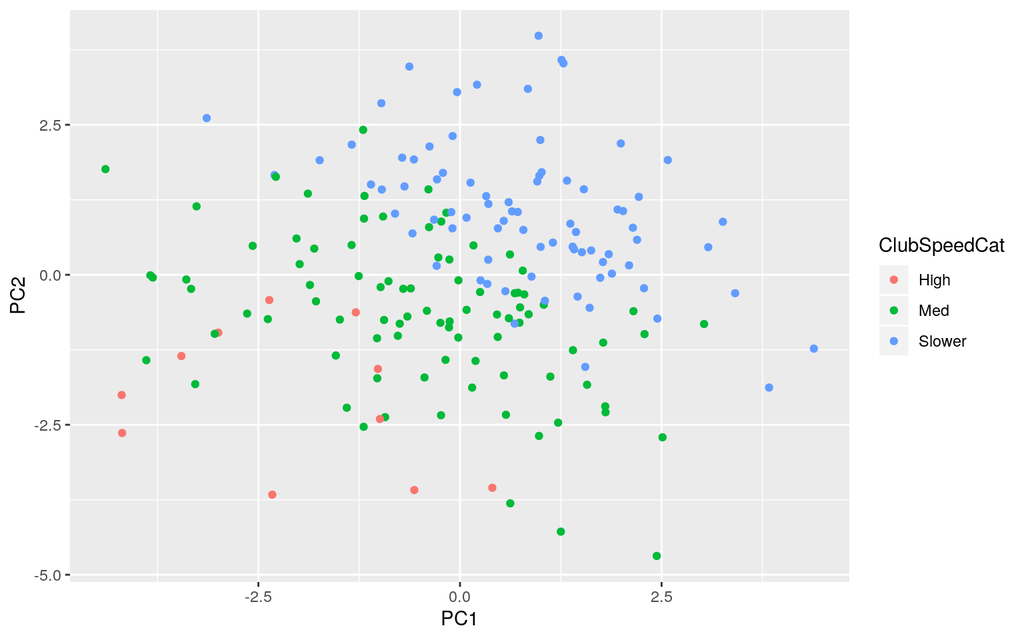

```r
finaldata %>% mutate(PC1 = golf_pca$scores[, 1], PC2 = golf_pca$scores[,
    2]) %>% ggplot(aes(x = PC1, y = PC2, color = ClubSpeedCat)) +
    geom_point()
```

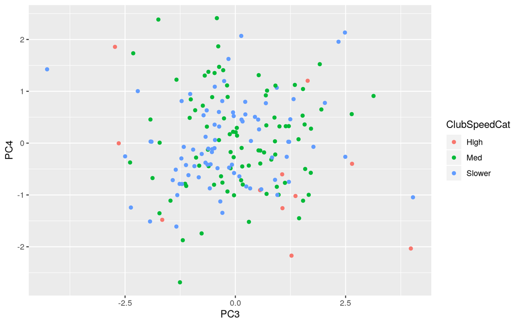

```r
finaldata %>% mutate(PC3 = golf_pca$scores[, 3], PC4 = golf_pca$scores[,
    4]) %>% ggplot(aes(x = PC3, y = PC4, color = ClubSpeedCat)) +
    geom_point()
```